# Session Analysis

Jonas Gehrlein @ Web3 Foundation

11/11/2022

```r
# Specify if code should be shown in export
show_code = FALSE
# Specify which network you would like to analyze. Must be "polkadot" or "kusama".
chain = "polkadot"
# Specify which session you would like to analyze. Must be >= 419 for Polkadot and >= 5994 for KSM.
session = 5391
```

# Descriptive metrics

|  | polkadot |
| --- | --- |
| Number of active Nominators: | **19231** |
| Number of active Validators: | **297** |
| Average commission: | **63.12%** |
| Number of validators with 100% commission: | **179** |
| Number of validators with <100% commission | **118** |
| Average commission for validators with <100% commission: | **7.19%** |
| Average selfstake in DOT | **5794.14** |
| Median selfstake in DOT | **0** |

# Decentralization

Decentralization is an important part of the polkadot network. The following graphs illustrate how votes are distributed across the different validators. One vote corresponds to a specification in the voting scheme. That means, one nominator can have up to 16 votes. This metric is pre-election algorithm, which means that the algorithm was not applied yet and votes have not been redistributed.

## Distribution of voters per validator

The following graphs plots the number of votes (pre-election-algorithm) for each (elected) validator in decreasing order. Note that the set of validators only contain those who are elected and therefore some votes (for not elected) validators are missing. The indicator line is showing a theoretical uniform distribution if all validators receive the same number of votes.

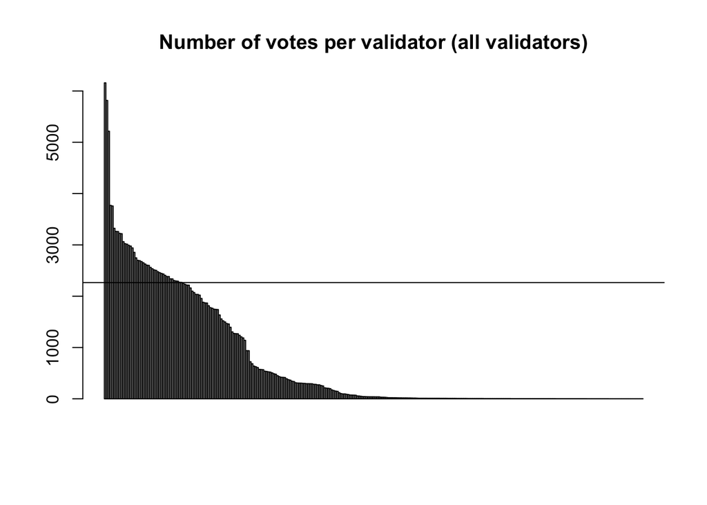

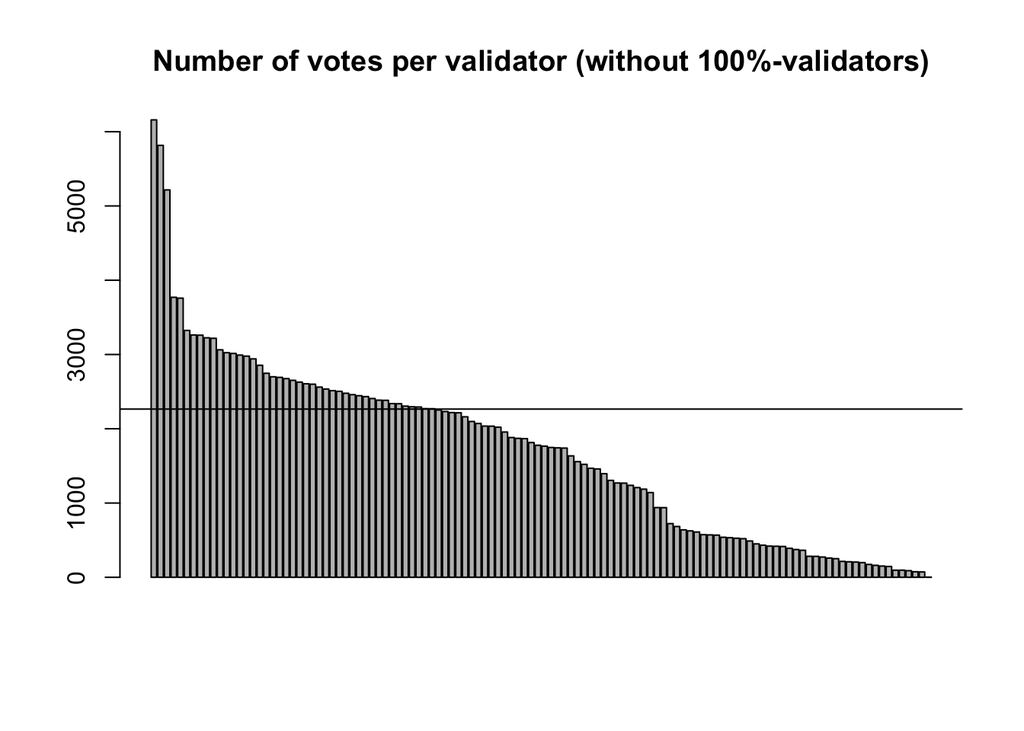

# Validator total stake

The following graph plots the total stake of the validators and sorts them.

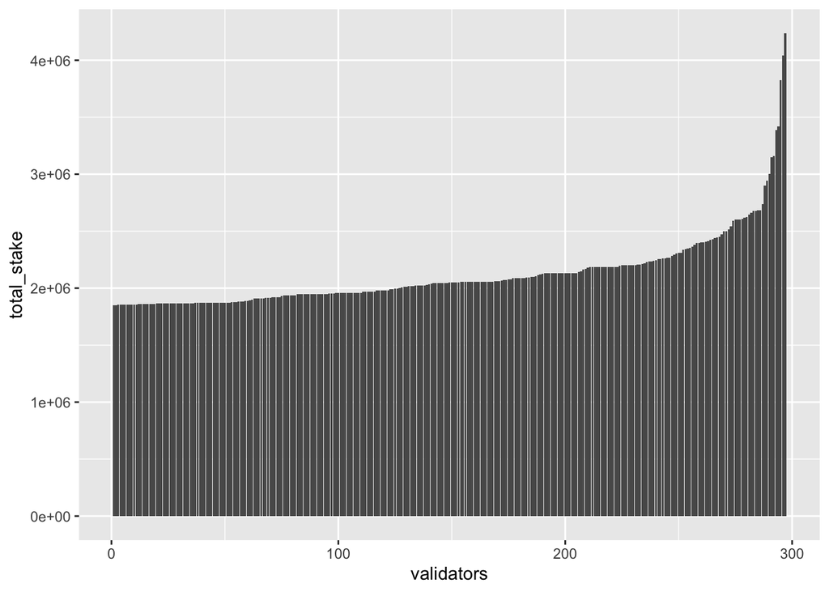

The minimum total stake is 1849120 in comparison to the average total stake of 2122975 which means that the minimum amount is 87.1003986% of the average.

# Voting Behavior of Nominators

The following graph shows a histogram of how many degrees the nominators have in their voting scheme. It can have values from 1 to 16 (as restricted by the election algorithm). The average number of degrees: **8.72** with a median of **8**

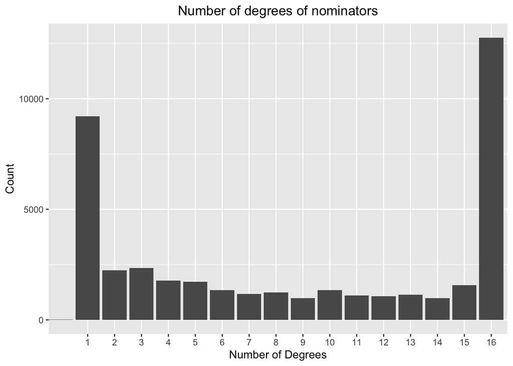

In the following graph, the nominators are grouped by how many degrees they have in their voting scheme. It further shows the total amount of bond held by each group (in % with respect to the total available staked bond).

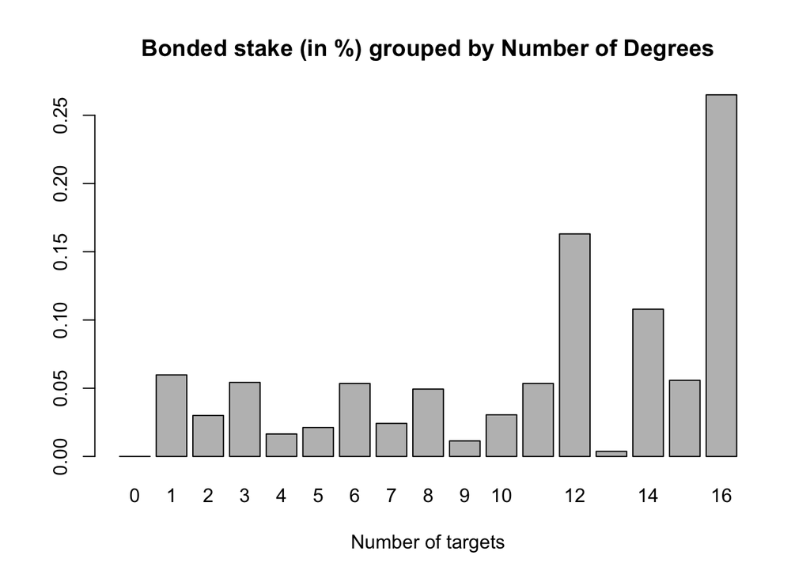